# Exploratory: Correlation Between Facebook Social Conectedness Index and UN’s Migrant Stock

# Data sources

- **Iso codes, region, and income level:** 📦 {wbstats} and 📦{countrycodes} R packages. This analysis excludes observations that are not present in the World Bank’s list of countries.
- [Facebook’s Social Connectedness Index](https://dataforgood.fb.com/docs/social-connectedness-index-methodology/) : It measures the relative probability of a Facebook friendship link between a given Facebook user in location *i* and a user in location *j.* Put differently, if this measure is twice as large, a Facebook user in *i* is about twice as likely to be connected with a given Facebook user in *j*. SCI excludes the following areas: Afghanistan, Western Sahara, China, Cuba, Iraq, Israel, Iran, North Korea, Russia, Syria, Somalia, South Sudan, Sudan, Venezuela, Yemen, Crimea, Jammu and Kashmir, Donetsk, Luhansk, Sevastopol, West Bank, and Gaza.
- [UN Migrant Stock By Origin And Destination](https://www.un.org/en/development/desa/population/migration/data/estimates2/estimates19.asp) : The total migrant stock at mid-year by origin and country of destination
- **World Bank’s Total Population** : Total population by country, accessed via 📦 {wbstats} in R.

# Clean data

Because the SCI data contains only information for 2019, the clean version of the “joint/merged” dataset only includes data for this year and for countries that are included in all the data sources (UN Stocks, Facebook SCI, World Bank’s Total Population). The *iso codes* were used to define **A unique bilateral identifier** for each combination of countries. A second identifier was created to identify the direction of the relationship between countries.

The variables *stocks_bilateral*, *flow_origin* and *flow_destination* were calculated using UN’s Migration Stock.

The table below shows 10 rows of the clean data:

| Year | ID | ID_direction | Origin | Destination | stocks_origin | stocks_destination | stocks_bilateral | flow_origin | flow_destination | scaled_sci | SP_POP_TOTL_origin | SP_POP_TOTL_destination | SP_TOTOAL_bilateral | Region_origin | Region_destination | Region_sub_origin | Region_sub_destination | Income_origin | Income_destination | flow_region | flow_subregion | flow_income | iso2_origin | iso2_destination |
| --- | --- | --- | --- | --- | --- | --- | --- | --- | --- | --- | --- | --- | --- | --- | --- | --- | --- | --- | --- | --- | --- | --- | --- | --- |
| 2019 | AEBH | BHAE | Bahrain | United Arab Emirates | 1969 | 4253 | 6222 | 135 | 212 | 293962 | 1641172 | 9770529 | 11411701 | Asia | Asia | Western Asia | Western Asia | High income | High income | Asia to Asia | Western Asia to Western Asia | High income to High income | BH | AE |
| 2019 | AEBH | AEBH | United Arab Emirates | Bahrain | 4253 | 1969 | 6222 | 212 | 135 | 293962 | 9770529 | 1641172 | 11411701 | Asia | Asia | Western Asia | Western Asia | High income | High income | Asia to Asia | Western Asia to Western Asia | High income to High income | AE | BH |
| 2019 | AEEG | EGAE | Egypt | United Arab Emirates | 886291 | 709 | 887000 | 61113 | 211 | 45385 | 100388073 | 9770529 | 110158602 | Africa | Asia | Northern Africa | Western Asia | Lower middle income | High income | Africa to Asia | Northern Africa to Western Asia | Lower middle income to High income | EG | AE |
| 2019 | AEEG | AEEG | United Arab Emirates | Egypt | 709 | 886291 | 887000 | 211 | 61113 | 45385 | 9770529 | 100388073 | 110158602 | Asia | Africa | Western Asia | Northern Africa | High income | Lower middle income | Asia to Africa | Western Asia to Northern Africa | High income to Lower middle income | AE | EG |
| 2019 | AEFR | FRAE | France | United Arab Emirates | 17874 | 862 | 18736 | 1232 | 47 | 4561 | 67059887 | 9770529 | 76830416 | Europe | Asia | Western Europe | Western Asia | High income | High income | Europe to Asia | Western Europe to Western Asia | High income to High income | FR | AE |
| 2019 | AEFR | AEFR | United Arab Emirates | France | 862 | 17874 | 18736 | 47 | 1232 | 4561 | 9770529 | 67059887 | 76830416 | Asia | Europe | Western Asia | Western Europe | High income | High income | Asia to Europe | Western Asia to Western Europe | High income to High income | AE | FR |
| 2019 | AEGB | AEGB | United Arab Emirates | United Kingdom | 11896 | 28760 | 40656 | 1420 | 1983 | 15131 | 9770529 | 66834405 | 76604934 | Asia | Europe | Western Asia | Northern Europe | High income | High income | Asia to Europe | Western Asia to Northern Europe | High income to High income | AE | GB |
| 2019 | AEGB | GBAE | United Kingdom | United Arab Emirates | 28760 | 11896 | 40656 | 1983 | 1420 | 15131 | 66834405 | 9770529 | 76604934 | Europe | Asia | Northern Europe | Western Asia | High income | High income | Europe to Asia | Northern Europe to Western Asia | High income to High income | GB | AE |
| 2019 | AEIN | INAE | India | United Arab Emirates | 3419875 | 11779 | 3431654 | 235832 | -198 | 45022 | 1366417754 | 9770529 | 1376188283 | Asia | Asia | Southern Asia | Western Asia | Lower middle income | High income | Asia to Asia | Southern Asia to Western Asia | Lower middle income to High income | IN | AE |
| 2019 | AEIN | AEIN | United Arab Emirates | India | 11779 | 3419875 | 3431654 | -198 | 235832 | 45022 | 9770529 | 1366417754 | 1376188283 | Asia | Asia | Western Asia | Southern Asia | High income | Lower middle income | Asia to Asia | Western Asia to Southern Asia | High income to Lower middle income | AE | IN |

# Correlation between SCI and UN bilateral stocks

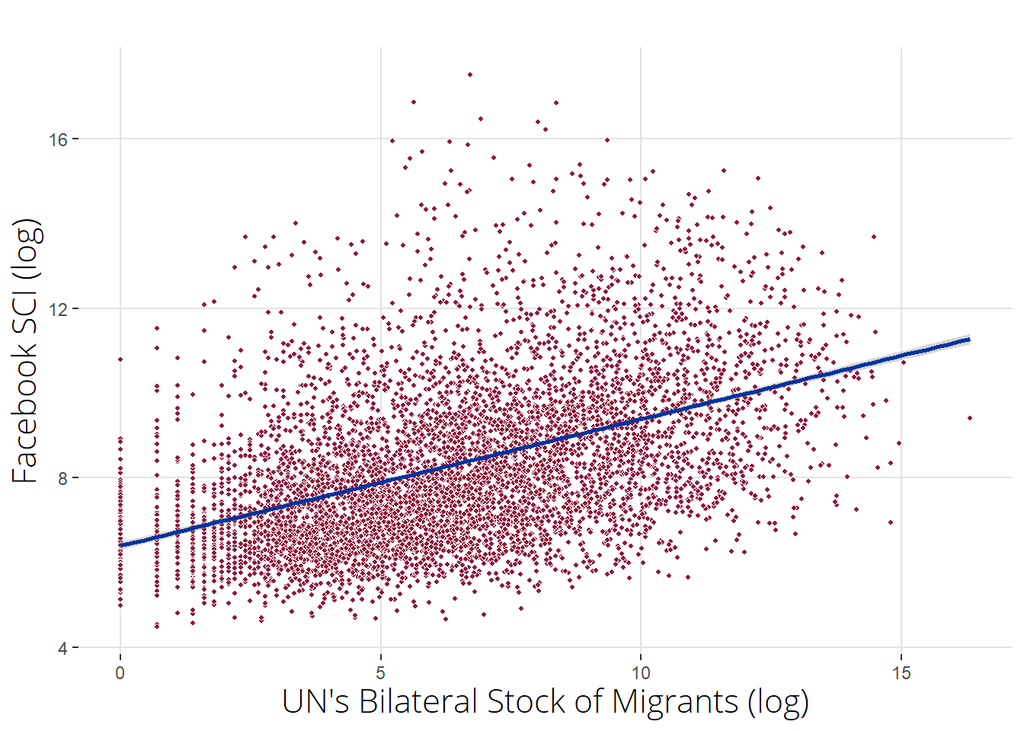

## By country’s income level

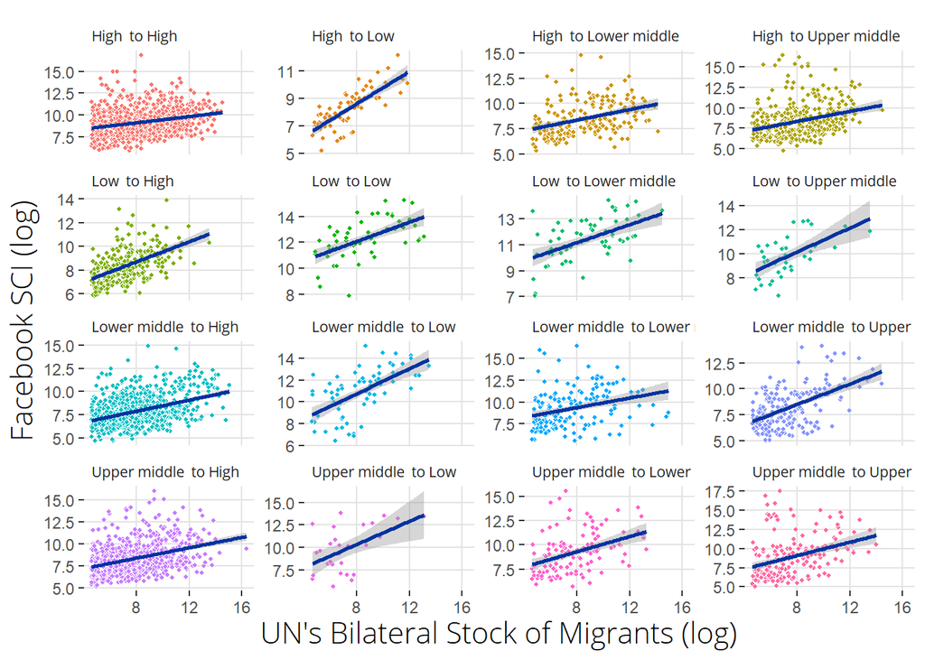

## By country’s region

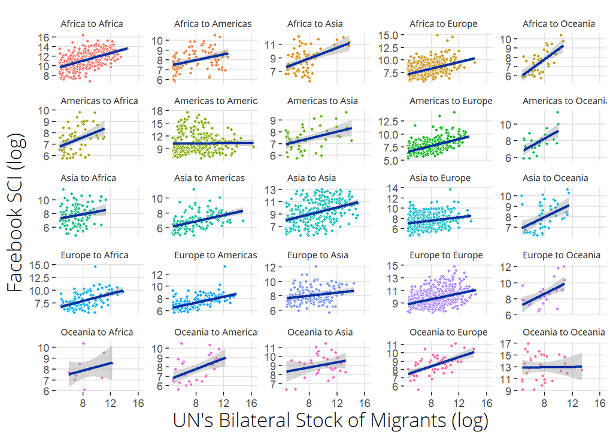